# bodomisc Vignette

Bodo Burger  
2018-08-21

# Plot Classification in 2 Dimensions

`PlotClassification2D()` visualizes the decision boundaries (respectively areas) of a model for a classification task in a 2-dimensional feature space.

The plot also shows the real data points and the respective class so that we can evaluate the decisions of the fitted model.

Model fitting is expected to be done via the interface of the mlr package as this allows the use of a great many models. The selected features have to be numeric to get a useful graph. The function creates a uniform grid in the 2-dimensional feature space and makes a model prediction for each grid point. For these predicitons all other numerical features are set to their mean, categorical features (factors) are set to the most frequent category (level).

## Nearest neighbor

The function is inspired by the figures you can find in the 2nd chapter of "Elements of Statistical Learning". We recreate the example for the nearest-neighbor method.

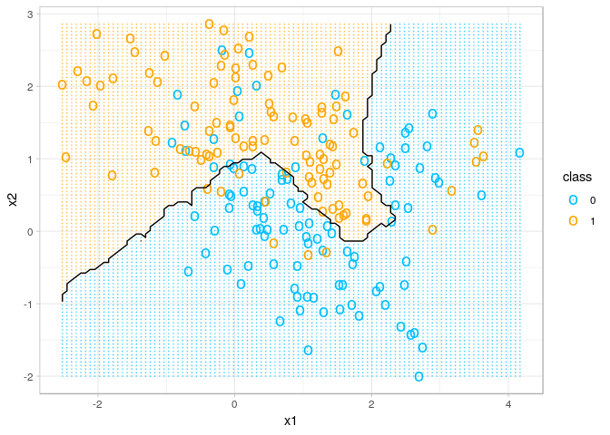

```r
library(bodomisc)
library(mlr)
library(ggplot2)
theme_set(theme_light())
library(ElemStatLearn)
me = ElemStatLearn::mixture.example
df = data.frame(x1 = me$x[,1], x2 = me$x[,2], y = factor(me$y))
tsk = makeClassifTask(data = df, target = "y")
spam.knn = train(makeLearner("classif.knn", k = 15), tsk)
plotClassification2D(spam.knn, tsk, features = c("x1", "x2"), colours = "ESL")
```

## Random Forest and Iris Dataset

The plot is also insightful for multiclassification problems like the Iris dataset.

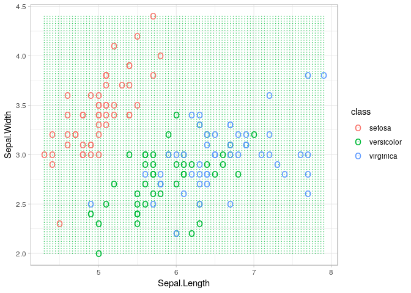

```r
iris.mod.rf = train(makeLearner("classif.randomForest"), iris.task)
plotClassification2D(iris.mod.rf, iris.task, features = c("Sepal.Length", "Sepal.Width"))
```

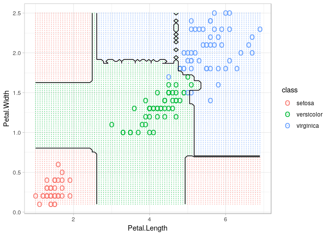

```r
plotClassification2D(iris.mod.rf, iris.task, features = c("Petal.Length", "Petal.Width"))
```

# Miscellaneous Helper Functions

## System and Session Information

```r
SystemInfo()
```

```
#> ------ General -----
#>    Operating system: Ubuntu 18.04.1 LTS (Linux 4.15.0-32-generic)
#>           R version: 3.5.1 (2018-07-02) Feather Spray
#>      User interface: RStudio (1.1.456)
#> ------ Session -----
#>   Working directory: /home/bodo/GitRepos/bodomisc/vignettes (change it using setwd() )
#> Packages (attached): base, bodomisc, datasets, devtools, ElemStatLearn, ggplot2, graphics, grDevices, methods, mlr, ParamHelpers, stats, utils (13 packages attached)
```

# Vignette help

- Never uses retina figures
- Has a smaller default figure size
- Uses a custom CSS stylesheet instead of the default Twitter Bootstrap style

## Styles

```
output:
  rmarkdown::html_vignette:
    css: mystyles.css
```

## Figures

You can enable figure captions by `fig_caption: yes` in YAML:

```
output:
  rmarkdown::html_vignette:
    fig_caption: yes
```

Then you can use the chunk option `fig.cap = "Your figure caption."` in **knitr**.

## More Examples

You can write math expressions, e.g. *Y* = *X**β *+* ϵ*, footnotes[1], and tables, e.g. using `knitr::kable()`.

Also a quote using `>`:

> "He who gives up [code] safety for [code] speed deserves neither." ([via](https://twitter.com/hadleywickham/status/504368538874703872))

# Notes

Render multiple knitr output formats:

```r
rmarkdown::render('vignettes/vignette.Rmd', output_format = 'all')
```

[1] A footnote here.